# kickstarter_part2_features_model_training

### Kickstarter dataset project

#### Description

- 1. Analyzing the dataset
- 2. Developing a model to predict the probability of campaign success
- 3. What are our recommendations to anyone who want to create a Kickstarter campaign?

## Feature engineering

Variables for the logistic regression:

- len(name) to take into account the name of the project
- if the name has all upper case words
- if the name contains ! or ?
- number of words in name
- does the name contains non alphanumeric characters
- duration between launch and deadline
- month of launch_date

Others

- goal in usd
- category (1-hot encoded)
- main category (1-hot encoded)
- country (1-hot encoding)

to predict target variable state

```python
def getDelta(a,b):
    '''Get diffence in days between launch and deadline'''
    return (a - b).days

# Duration of the project
df_final['duration'] = df_final.apply(lambda x: getDelta(x['deadline'],x['launched']),axis = 1)
```

```python
df_final['month'] = df_final['launched'].dt.month
df_final['year_month'] = df_final['launched'].map(lambda x: str(x.year) + "-" + str(x.month))
```

```python
import re

def has_non_chars(name):
    for c in name:
        if not c.isalpha() and c!='?' and c!='!':
            return 1
    return 0

def has_exclamation_interrogation(name):
    if ("!" in name or "?" in name):
        return 1
    return 0

def has_upper(name):
    for word in name.split(' '):
        if word.isupper() and len(re.sub(r'\W+', '', word))>1:
            return 1
    return 0
```

```python
df_final['len_name'] = df_final.name.str.len()
```

```python
df_final['name_nb_words'] = df_final.name.apply(lambda x: len(str(x).split(' ')))
```

```python
df_final['name_non_chars'] = df_final.name.apply(has_non_chars)
```

```python
df_final['name_has_symbol'] = df_final.name.apply(has_exclamation_interrogation)
```

```python
df_final['name_upper'] = df_final.name.apply(has_upper)
```

```python
df_final.head()
```

|  | ID | name | category | main_category | currency | deadline | launched | state | backers | country | ... | usd_goal | cat_full | duration | month | year_month | len_name | name_nb_words | name_non_chars | name_has_symbol | name_upper |
| --- | --- | --- | --- | --- | --- | --- | --- | --- | --- | --- | --- | --- | --- | --- | --- | --- | --- | --- | --- | --- | --- |
| 0 | 1000002330 | The Songs of Adelaide & Abullah | Poetry | Publishing | GBP | 2015-10-09 11:36:00 | 2015-08-11 12:12:28 | failed | 0 | GB | ... | 1533.954368 | Publishing-Poetry | 58 | 8 | 2015-8 | 31 | 6 | 1 | 0 | 0 |
| 1 | 1000004038 | Where is Hank? | Narrative Film | Film & Video | USD | 2013-02-26 00:20:50 | 2013-01-12 00:20:50 | failed | 3 | US | ... | 45000.000000 | Film & Video-Narrative Film | 45 | 1 | 2013-1 | 14 | 3 | 1 | 1 | 0 |
| 2 | 1000007540 | ToshiCapital Rekordz Needs Help to Complete Album | Music | Music | USD | 2012-04-16 04:24:11 | 2012-03-17 03:24:11 | failed | 1 | US | ... | 5000.000000 | Music-Music | 30 | 3 | 2012-3 | 49 | 7 | 1 | 0 | 0 |
| 3 | 1000014025 | Monarch Espresso Bar | Restaurants | Food | USD | 2016-04-01 13:38:27 | 2016-02-26 13:38:27 | successful | 224 | US | ... | 50000.000000 | Food-Restaurants | 35 | 2 | 2016-2 | 20 | 3 | 1 | 0 | 0 |
| 4 | 1000023410 | Support Solar Roasted Coffee & Green Energy! ... | Food | Food | USD | 2014-12-21 18:30:44 | 2014-12-01 18:30:44 | successful | 16 | US | ... | 1000.000000 | Food-Food | 20 | 12 | 2014-12 | 60 | 9 | 1 | 1 | 0 |

5 rows × 21 columns

## Dealing with outliers

Let's try to deal with outliers by using the z-score for usd_goal and real_usd_pledged

```python
df_final.describe()
```

|  | ID | backers | real_usd_pledged | usd_goal | duration | month | len_name | name_nb_words | name_non_chars | name_has_symbol | name_upper |
| --- | --- | --- | --- | --- | --- | --- | --- | --- | --- | --- | --- |
| count | 2.816370e+05 | 281637.000000 | 2.816370e+05 | 2.816370e+05 | 281637.000000 | 281637.000000 | 281637.000000 | 281637.000000 | 281637.000000 | 281637.000000 | 281637.000000 |
| mean | 1.074975e+09 | 111.936262 | 9.289149e+03 | 4.117401e+04 | 33.976253 | 6.372977 | 34.023541 | 5.565522 | 0.963318 | 0.105174 | 0.207533 |
| std | 6.194734e+08 | 996.647439 | 9.303738e+04 | 1.083168e+06 | 12.893991 | 3.274156 | 15.917254 | 2.749596 | 0.187980 | 0.306779 | 0.405541 |
| min | 5.971000e+03 | 0.000000 | 0.000000e+00 | 1.000000e-02 | 1.000000 | 1.000000 | 1.000000 | 1.000000 | 0.000000 | 0.000000 | 0.000000 |
| 25% | 5.372636e+08 | 2.000000 | 5.000000e+01 | 2.000000e+03 | 30.000000 | 4.000000 | 20.000000 | 3.000000 | 1.000000 | 0.000000 | 0.000000 |
| 50% | 1.075993e+09 | 15.000000 | 7.910000e+02 | 5.000000e+03 | 30.000000 | 6.000000 | 33.000000 | 5.000000 | 1.000000 | 0.000000 | 0.000000 |
| 75% | 1.611428e+09 | 62.000000 | 4.500000e+03 | 1.500000e+04 | 36.000000 | 9.000000 | 48.000000 | 8.000000 | 1.000000 | 0.000000 | 0.000000 |
| max | 2.147476e+09 | 219382.000000 | 2.033899e+07 | 1.663627e+08 | 92.000000 | 12.000000 | 85.000000 | 41.000000 | 1.000000 | 1.000000 | 1.000000 |

```python
from scipy import stats
import numpy as np
z = np.abs(stats.zscore(df_final['usd_goal']))
print(z)
```

```
[0.03659648 0.00353223 0.03339656 ... 0.0373664  0.00108387 0.03628162]
```

```python
z = np.abs(stats.zscore(df_final['usd_goal']))
outliers_usd_goal = np.where(z > 3)[0].tolist()
```

```python
df_final.iloc[outliers_usd_goal].shape
```

```
(265, 21)
```

```python
df_final.describe()
```

|  | ID | backers | real_usd_pledged | usd_goal | duration | month | len_name | name_nb_words | name_non_chars | name_has_symbol | name_upper |
| --- | --- | --- | --- | --- | --- | --- | --- | --- | --- | --- | --- |
| count | 2.816370e+05 | 281637.000000 | 2.816370e+05 | 2.816370e+05 | 281637.000000 | 281637.000000 | 281637.000000 | 281637.000000 | 281637.000000 | 281637.000000 | 281637.000000 |
| mean | 1.074975e+09 | 111.936262 | 9.289149e+03 | 4.117401e+04 | 33.976253 | 6.372977 | 34.023541 | 5.565522 | 0.963318 | 0.105174 | 0.207533 |
| std | 6.194734e+08 | 996.647439 | 9.303738e+04 | 1.083168e+06 | 12.893991 | 3.274156 | 15.917254 | 2.749596 | 0.187980 | 0.306779 | 0.405541 |
| min | 5.971000e+03 | 0.000000 | 0.000000e+00 | 1.000000e-02 | 1.000000 | 1.000000 | 1.000000 | 1.000000 | 0.000000 | 0.000000 | 0.000000 |
| 25% | 5.372636e+08 | 2.000000 | 5.000000e+01 | 2.000000e+03 | 30.000000 | 4.000000 | 20.000000 | 3.000000 | 1.000000 | 0.000000 | 0.000000 |
| 50% | 1.075993e+09 | 15.000000 | 7.910000e+02 | 5.000000e+03 | 30.000000 | 6.000000 | 33.000000 | 5.000000 | 1.000000 | 0.000000 | 0.000000 |
| 75% | 1.611428e+09 | 62.000000 | 4.500000e+03 | 1.500000e+04 | 36.000000 | 9.000000 | 48.000000 | 8.000000 | 1.000000 | 0.000000 | 0.000000 |
| max | 2.147476e+09 | 219382.000000 | 2.033899e+07 | 1.663627e+08 | 92.000000 | 12.000000 | 85.000000 | 41.000000 | 1.000000 | 1.000000 | 1.000000 |

```python
df_final.loc[~df_final.index.isin(outliers_usd_goal)].describe()
```

|  | ID | backers | real_usd_pledged | usd_goal | duration | month | len_name | name_nb_words | name_non_chars | name_has_symbol | name_upper |
| --- | --- | --- | --- | --- | --- | --- | --- | --- | --- | --- | --- |
| count | 2.813720e+05 | 281372.000000 | 2.813720e+05 | 2.813720e+05 | 281372.000000 | 281372.000000 | 281372.000000 | 281372.000000 | 281372.000000 | 281372.000000 | 281372.000000 |
| mean | 1.074978e+09 | 112.021775 | 9.291648e+03 | 2.192021e+04 | 33.965995 | 6.373353 | 34.026659 | 5.566115 | 0.963337 | 0.105209 | 0.207505 |
| std | 6.194722e+08 | 997.100542 | 9.306623e+04 | 9.515329e+04 | 12.885480 | 3.274189 | 15.916732 | 2.749570 | 0.187934 | 0.306824 | 0.405521 |
| min | 5.971000e+03 | 0.000000 | 0.000000e+00 | 1.000000e-02 | 1.000000 | 1.000000 | 1.000000 | 1.000000 | 0.000000 | 0.000000 | 0.000000 |
| 25% | 5.372407e+08 | 2.000000 | 5.000000e+01 | 2.000000e+03 | 30.000000 | 4.000000 | 20.000000 | 3.000000 | 1.000000 | 0.000000 | 0.000000 |
| 50% | 1.076004e+09 | 15.000000 | 7.945924e+02 | 5.000000e+03 | 30.000000 | 6.000000 | 33.000000 | 5.000000 | 1.000000 | 0.000000 | 0.000000 |
| 75% | 1.611415e+09 | 62.000000 | 4.505000e+03 | 1.500000e+04 | 36.000000 | 9.000000 | 48.000000 | 8.000000 | 1.000000 | 0.000000 | 0.000000 |
| max | 2.147476e+09 | 219382.000000 | 2.033899e+07 | 3.258300e+06 | 92.000000 | 12.000000 | 85.000000 | 41.000000 | 1.000000 | 1.000000 | 1.000000 |

```python
df_final.shape
```

```
(281637, 21)
```

```python
df_final.loc[~df_final.index.isin(outliers_usd_goal)].shape
```

```
(281372, 21)
```

```python
df_final2 = df_final.loc[~df_final.index.isin(outliers_usd_goal)].copy()
```

```python
z = np.abs(stats.zscore(df_final['real_usd_pledged']))
outliers_usd_pledged = np.where(z > 3)[0].tolist()
```

```python
len(outliers_usd_pledged)
```

```
1042
```

```python
df_final2 = df_final2.loc[~df_final2.index.isin(outliers_usd_pledged)].copy()
```

```python
df_final2.shape
```

```
(280332, 21)
```

```python
df_final2.describe()
```

|  | ID | backers | real_usd_pledged | usd_goal | duration | month | len_name | name_nb_words | name_non_chars | name_has_symbol | name_upper |
| --- | --- | --- | --- | --- | --- | --- | --- | --- | --- | --- | --- |
| count | 2.803320e+05 | 280332.000000 | 280332.000000 | 2.803320e+05 | 280332.000000 | 280332.000000 | 280332.000000 | 280332.000000 | 280332.000000 | 280332.000000 | 280332.000000 |
| mean | 1.074964e+09 | 83.907709 | 6180.076882 | 2.145509e+04 | 33.958271 | 6.373379 | 34.003642 | 5.562936 | 0.963304 | 0.105332 | 0.207115 |
| std | 6.195026e+08 | 294.795406 | 18786.237435 | 9.384953e+04 | 12.895056 | 3.274712 | 15.914811 | 2.749587 | 0.188014 | 0.306982 | 0.405239 |
| min | 5.971000e+03 | 0.000000 | 0.000000 | 1.000000e-02 | 1.000000 | 1.000000 | 1.000000 | 1.000000 | 0.000000 | 0.000000 | 0.000000 |
| 25% | 5.372233e+08 | 2.000000 | 48.458339 | 2.000000e+03 | 30.000000 | 4.000000 | 20.000000 | 3.000000 | 1.000000 | 0.000000 | 0.000000 |
| 50% | 1.075901e+09 | 15.000000 | 780.000000 | 5.000000e+03 | 30.000000 | 6.000000 | 33.000000 | 5.000000 | 1.000000 | 0.000000 | 0.000000 |
| 75% | 1.611481e+09 | 61.000000 | 4401.000000 | 1.500000e+04 | 36.000000 | 9.000000 | 48.000000 | 8.000000 | 1.000000 | 0.000000 | 0.000000 |
| max | 2.147472e+09 | 11749.000000 | 287694.419180 | 3.258300e+06 | 92.000000 | 12.000000 | 85.000000 | 41.000000 | 1.000000 | 1.000000 | 1.000000 |

I am not sure I will be using df_final2 in the end because dealing with outliers seems to be quite arduous in the case of this dataframe as there are still 'outliers'. I would be interesting to compare different training with different samples.

```python
del df_final2
```

## I. Let's prepare the dataset to train the model

```python
df_final.columns
```

```
Index(['ID', 'name', 'category', 'main_category', 'currency', 'deadline',
       'launched', 'state', 'backers', 'country', 'real_usd_pledged',
       'usd_goal', 'cat_full', 'duration', 'month', 'year_month', 'len_name',
       'name_nb_words', 'name_non_chars', 'name_has_symbol', 'name_upper'],
      dtype='object')
```

```python
ks = df_final.drop(['ID','name','deadline','launched','year_month', 'backers', 'real_usd_pledged'], axis=1).copy()
```

```python
ks.columns
```

```
Index(['category', 'main_category', 'currency', 'state', 'country', 'usd_goal',
       'cat_full', 'duration', 'month', 'len_name', 'name_nb_words',
       'name_non_chars', 'name_has_symbol', 'name_upper'],
      dtype='object')
```

```python
ks['usd_goal_corrected'] = np.log1p(ks['usd_goal'])
```

```python
ks['state'] = ks.state.map(dict(successful=1, failed=0))
```

## 1. Generating html report with pandas profiling

```python
profile = ProfileReport(ks, title="Pandas Profiling Report Kickstarter")
profile.to_file('kickstarterds.html')
```

## 2. Explore manually

[figure not shown]

```python
# ## This heatmap is also available from pandas-profiling html file.
# corr = ks.corr()
# dims = (16, 10)
# fig, ax = plt.subplots(figsize = dims)
# sns.heatmap(corr,
#             xticklabels=corr.columns.values,
#             yticklabels=corr.columns.values,ax = ax, cmap="Blues")
```

```python
# We'll drop name_nb_words because it's highly correlated with len_name
ks = ks.drop(['name_nb_words'], axis=1)
# We can drop currency too as the currency is explained by the country
ks = ks.drop(['currency'], axis=1)
# We can drop category and main_category as it's encoded in cat_full
ks = ks.drop(['category','main_category'], axis=1)
```

```python
ks.columns
```

```
Index(['state', 'country', 'usd_goal', 'cat_full', 'duration', 'month',
       'len_name', 'name_non_chars', 'name_has_symbol', 'name_upper',
       'usd_goal_corrected'],
      dtype='object')
```

```python
ks.state.value_counts(normalize=True)
```

```
0    0.598267
1    0.401733
Name: state, dtype: float64
```

We may consider the dataset is balanced because of the 60/40 % ratio

```python
ks.dtypes
```

```
state                   int64
country                object
usd_goal              float64
cat_full               object
duration                int64
month                   int64
len_name                int64
name_non_chars          int64
name_has_symbol         int64
name_upper              int64
usd_goal_corrected    float64
dtype: object
```

```python
ks.describe(include='all')
```

|  | state | country | usd_goal | cat_full | duration | month | len_name | name_non_chars | name_has_symbol | name_upper | usd_goal_corrected |
| --- | --- | --- | --- | --- | --- | --- | --- | --- | --- | --- | --- |
| count | 281637.000000 | 281637 | 2.816370e+05 | 281637 | 281637.000000 | 281637.000000 | 281637.000000 | 281637.000000 | 281637.000000 | 281637.000000 | 281637.000000 |
| unique | NaN | 21 | NaN | 165 | NaN | NaN | NaN | NaN | NaN | NaN | NaN |
| top | NaN | US | NaN | Design-Product Design | NaN | NaN | NaN | NaN | NaN | NaN | NaN |
| freq | NaN | 229818 | NaN | 14538 | NaN | NaN | NaN | NaN | NaN | NaN | NaN |
| mean | 0.401733 | NaN | 4.117401e+04 | NaN | 33.976253 | 6.372977 | 34.023541 | 0.963318 | 0.105174 | 0.207533 | 8.587772 |
| std | 0.490249 | NaN | 1.083168e+06 | NaN | 12.893991 | 3.274156 | 15.917254 | 0.187980 | 0.306779 | 0.405541 | 1.659265 |
| min | 0.000000 | NaN | 1.000000e-02 | NaN | 1.000000 | 1.000000 | 1.000000 | 0.000000 | 0.000000 | 0.000000 | 0.009950 |
| 25% | 0.000000 | NaN | 2.000000e+03 | NaN | 30.000000 | 4.000000 | 20.000000 | 1.000000 | 0.000000 | 0.000000 | 7.601402 |
| 50% | 0.000000 | NaN | 5.000000e+03 | NaN | 30.000000 | 6.000000 | 33.000000 | 1.000000 | 0.000000 | 0.000000 | 8.517393 |
| 75% | 1.000000 | NaN | 1.500000e+04 | NaN | 36.000000 | 9.000000 | 48.000000 | 1.000000 | 0.000000 | 0.000000 | 9.615872 |
| max | 1.000000 | NaN | 1.663627e+08 | NaN | 92.000000 | 12.000000 | 85.000000 | 1.000000 | 1.000000 | 1.000000 | 18.929681 |

## II. Model training

```python
y = ks.state
x = ks.drop(['state','usd_goal'], axis = 1)
```

```python
from sklearn.model_selection import train_test_split
x_train, x_test, y_train, y_test = train_test_split(x, y, test_size=0.2, random_state=SEED)
```

```python
print('x_train.shape:', x_train.shape)
print('y_train.shape:', y_train.shape)
print('x_test.shape :', x_test.shape)
print('y_test.shape :', y_test.shape)
```

```
x_train.shape: (225309, 9)
y_train.shape: (225309,)
x_test.shape : (56328, 9)
y_test.shape : (56328,)
```

```python
x_train.columns
```

```
Index(['country', 'cat_full', 'duration', 'month', 'len_name',
       'name_non_chars', 'name_has_symbol', 'name_upper',
       'usd_goal_corrected'],
      dtype='object')
```

```python
from pprint import pprint
import mlflow

def fetch_logged_data(run_id):
    client = mlflow.tracking.MlflowClient()
    data = client.get_run(run_id).data
    tags = {k: v for k, v in data.tags.items() if not k.startswith("mlflow.")}
    artifacts = [f.path for f in client.list_artifacts(run_id, "model")]
    return data.params, data.metrics, tags, artifacts

# enable autologging
mlflow.sklearn.autolog()
```

```python
from sklearn.dummy import DummyClassifier
# define model

model = DummyClassifier(strategy='uniform', random_state=42)
with mlflow.start_run() as run:
    model.fit(x_train, y_train)


# fetch logged data
params, metrics, tags, artifacts = fetch_logged_data(run.info.run_id)

pprint(params)
pprint(metrics)
pprint(tags)
pprint(artifacts)
```

[output not shown]

```
{'constant': 'None', 'random_state': '42', 'strategy': 'uniform'}
{'training_accuracy_score': 0.500264081772144,
 'training_f1_score': 0.5051236324432034,
 'training_log_loss': 0.6931471805599451,
 'training_precision_score': 0.5195800439022963,
 'training_recall_score': 0.500264081772144,
 'training_roc_auc_score': 0.5,
 'training_score': 0.500264081772144}
{'estimator_class': 'sklearn.dummy.DummyClassifier',
 'estimator_name': 'DummyClassifier'}
['model/MLmodel', 'model/conda.yaml', 'model/model.pkl']
```

### Preprocessing

```python
from sklearn.compose import ColumnTransformer
from sklearn.impute import SimpleImputer
from sklearn.linear_model import LogisticRegression
from sklearn.model_selection import GridSearchCV, StratifiedKFold
from sklearn.pipeline import make_pipeline, Pipeline
from sklearn.preprocessing import StandardScaler, RobustScaler, OneHotEncoder

numeric_features = ['usd_goal_corrected', 'duration', 'len_name']

numeric_transformer = Pipeline(
    steps=[
        ("imputer", SimpleImputer(strategy="mean")),
        ("scaler", RobustScaler()),
    ]
)

categorical_features = ['country', 'cat_full', 'month', 'name_non_chars', 'name_has_symbol', 'name_upper']
categorical_transformer = Pipeline(
    steps=[("onehot", OneHotEncoder(handle_unknown="ignore"))]
)

preprocessing = ColumnTransformer(
    transformers=[
        ("num", numeric_transformer, numeric_features),
        ("cat", categorical_transformer, categorical_features),
    ],
    remainder="passthrough",
)
```

```python
def predict_plot(X, y, classifier, classifier_name):
    # predict probabilities
    lr_probs = classifier.predict_proba(X)
    # keep probabilities for the positive outcome only
    lr_probs = lr_probs[:, 1]
    # predict class values
    yhat = classifier.predict(X)
    precision = precision_score(y, yhat)
    lr_precision, lr_recall, _ = precision_recall_curve(y, lr_probs)
    lr_f1, lr_auc = f1_score(y, yhat), auc(lr_recall, lr_precision)
    # summarize scores
    print(classifier_name+': precision=%.3f auc=%.3f' % (precision, lr_auc))
    # plot the precision-recall curves
    no_skill = len(y[y==1]) / len(y)
    pyplot.plot([0, 1], [no_skill, no_skill], linestyle='--', label='No Skill')
    pyplot.plot(lr_recall, lr_precision, marker='.', label=classifier_name)
    # axis labels
    pyplot.xlabel('Recall')
    pyplot.ylabel('Precision')
    # show the legend
    pyplot.legend()
    # show the plot
    pyplot.show()
```

[output not shown]

```
Logistic Regression: precision=0.626 auc=0.624
```

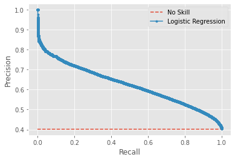

```python
# precision-recall curve and f1 for evaluation purposes

from sklearn.datasets import make_classification
from sklearn.linear_model import LogisticRegression
from sklearn.model_selection import train_test_split
from sklearn.metrics import precision_recall_curve
from sklearn.metrics import f1_score
from sklearn.metrics import auc
from matplotlib import pyplot

lr = LogisticRegression(solver='liblinear')
# model = LogisticRegression(solver='lbfgs')
model = Pipeline([('preprocessing', preprocessing),
                ('lr',lr)])
model.fit(x_train, y_train)

predict_plot(x_train, y_train, model, "Logistic Regression")
```

```
Logistic Regression: precision=0.624 auc=0.622
```

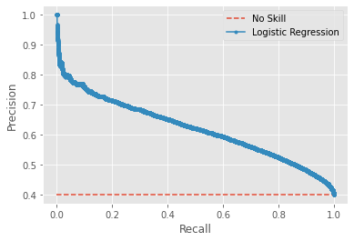

```python
predict_plot(x_test, y_test, model, "Logistic Regression")
```

[output not shown]

```
GBM: precision=0.646 auc=0.653
```

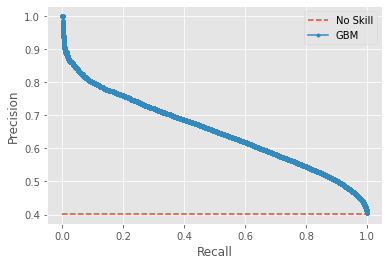

```python
from lightgbm import LGBMClassifier

# #Specifying the parameter
# params={}
# params['learning_rate']=0.03
# params['boosting_type']='gbdt' #GradientBoostingDecisionTree
# params['objective']='binary' #Binary target feature
# params['metric']='binary_logloss' #metric for binary classification
# params['max_depth']=10
# #train the model
# clf=lgb.train(params,d_train,100) #train the model on 100 epochs
# #prediction on the test set
# y_pred=clf.predict(X_test)

clf = make_pipeline(
    preprocessing,
    LGBMClassifier()
)

clf.fit(x_train, y_train)

predict_plot(x_train, y_train, clf, 'GBM')
```

```
GBM: precision=0.641 auc=0.647
```

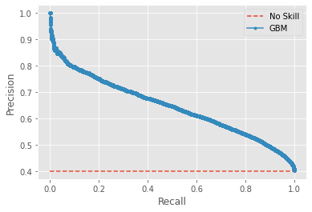

```python
predict_plot(x_test, y_test, clf, 'GBM')
```

```python
make_pipeline(preprocessing, clf).get_params()
```

[output not shown]

[output cut: 144 more lines]

```
 'pipeline__lgbmclassifier__max_depth': -1,
 'pipeline__lgbmclassifier__min_child_samples': 20,
 'pipeline__lgbmclassifier__min_child_weight': 0.001,
 'pipeline__lgbmclassifier__min_split_gain': 0.0,
 'pipeline__lgbmclassifier__n_estimators': 100,
 'pipeline__lgbmclassifier__n_jobs': -1,
 'pipeline__lgbmclassifier__num_leaves': 31,
 'pipeline__lgbmclassifier__objective': None,
 'pipeline__lgbmclassifier__random_state': None,
 'pipeline__lgbmclassifier__reg_alpha': 0.0,
 'pipeline__lgbmclassifier__reg_lambda': 0.0,
 'pipeline__lgbmclassifier__silent': True,
 'pipeline__lgbmclassifier__subsample': 1.0,
 'pipeline__lgbmclassifier__subsample_for_bin': 200000,
 'pipeline__lgbmclassifier__subsample_freq': 0}
```

[output not shown]

```
GBM: precision=0.661 auc=0.684
```

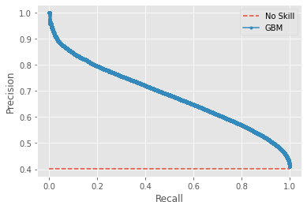

```python
clf = make_pipeline(
    preprocessing,
    LGBMClassifier(learning_rate=0.7, boosting_type="gbdt", objective='binary', metric='precision', max_depth=-1)
)

clf.fit(x_train, y_train)

predict_plot(x_train, y_train, clf, 'GBM')
```

```
GBM: precision=0.623 auc=0.637
```

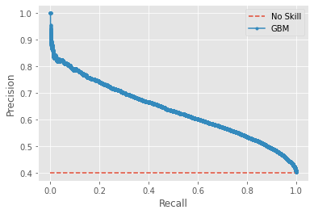

```python
predict_plot(x_test, y_test, clf, 'GBM')
```

```python
from sklearn.base import BaseEstimator
class ClfSwitcher(BaseEstimator):

    def __init__(
        self,
        estimator = LogisticRegression(),
    ):
        """
        A Custom BaseEstimator that can switch between classifiers.
        :param estimator: sklearn object - The classifier
        """

        self.estimator = estimator


    def fit(self, X, y=None, **kwargs):
        self.estimator.fit(X, y)
        return self


    def predict(self, X, y=None):
        return self.estimator.predict(X)


    def predict_proba(self, X):
        return self.estimator.predict_proba(X)


    def score(self, X, y):
        return self.estimator.score(X, y)
```

```python
pipeline = Pipeline([('preprocessing', preprocessing), ('clf', ClfSwitcher())])

parameters = [
    {
        'clf__estimator': [LogisticRegression()],
        'clf__estimator__solver': ["lbfgs", "liblinear"],
        "clf__estimator__penalty": ["l2"],
        "clf__estimator__C": [0.1, 0.2, 0.3, 0.5, 1.0],
        "clf__estimator__max_iter": [100, 1000, 2000],
    },
    {
        'clf__estimator': [LogisticRegression()],
        'clf__estimator__solver': ["liblinear"],
        "clf__estimator__penalty": ["l1"],
        "clf__estimator__C": [0.1, 0.2, 0.3, 0.5, 1.0],
        "clf__estimator__max_iter": [100, 1000, 2000],
    },
]

gscv = GridSearchCV(pipeline, parameters, cv=2, n_jobs=-1, verbose=3)
gs_model = gscv.fit(x_train, y_train)

print(gs_model.best_params_, gs_model.best_score_)
```

```
Fitting 2 folds for each of 45 candidates, totalling 90 fits
```

```
[Parallel(n_jobs=-1)]: Using backend LokyBackend with 12 concurrent workers.
[Parallel(n_jobs=-1)]: Done   8 tasks      | elapsed:    7.4s
[Parallel(n_jobs=-1)]: Done  90 out of  90 | elapsed:  2.5min finished
```

```
{'clf__estimator': LogisticRegression(C=0.3), 'clf__estimator__C': 0.3, 'clf__estimator__max_iter': 100, 'clf__estimator__penalty': 'l2', 'clf__estimator__solver': 'lbfgs'} 0.6767994140970223
```

```python
from sklearn.metrics import accuracy_score, log_loss
from sklearn.neighbors import KNeighborsClassifier
from sklearn.svm import SVC, LinearSVC, NuSVC
from sklearn.tree import DecisionTreeClassifier
from sklearn.ensemble import RandomForestClassifier, AdaBoostClassifier, GradientBoostingClassifier
from sklearn.discriminant_analysis import LinearDiscriminantAnalysis
from sklearn.discriminant_analysis import QuadraticDiscriminantAnalysis
classifiers = [
    DecisionTreeClassifier(),
    RandomForestClassifier(),
    GradientBoostingClassifier()
    ]
for classifier in classifiers:
    pipe = Pipeline(steps=[('preprocessing', preprocessing),
                      ('classifier', classifier)])
    pipe.fit(x_train, y_train)
    print(classifier)
    print("model score: %.3f" % pipe.score(x_test, y_test))
```

[output not shown]

### Without sklearn pipelines

```python
# x = pd.get_dummies(x, columns = ['month','category','main_category','country'])
x = pd.get_dummies(x, columns = ['month','cat_full','country'])
```

```python
from sklearn.preprocessing import RobustScaler
num_cols = ['usd_goal_corrected', 'duration', 'len_name']

transformer = RobustScaler().fit(x[num_cols])
```

```python
x[num_cols] = transformer.transform(x[num_cols])
```

```python
x.describe()
```

|  | duration | len_name | name_non_chars | name_has_symbol | name_upper | usd_goal_corrected | month_1 | month_2 | month_3 | month_4 | ... | country_IE | country_IT | country_LU | country_MX | country_NL | country_NO | country_NZ | country_SE | country_SG | country_US |
| --- | --- | --- | --- | --- | --- | --- | --- | --- | --- | --- | --- | --- | --- | --- | --- | --- | --- | --- | --- | --- | --- |
| count | 281637.000000 | 281637.000000 | 281637.000000 | 281637.000000 | 281637.000000 | 281637.000000 | 281637.000000 | 281637.000000 | 281637.000000 | 281637.000000 | ... | 281637.000000 | 281637.000000 | 281637.000000 | 281637.000000 | 281637.000000 | 281637.000000 | 281637.000000 | 281637.000000 | 281637.000000 | 281637.000000 |
| mean | 0.662709 | 0.036555 | 0.963318 | 0.105174 | 0.207533 | 0.034937 | 0.072846 | 0.080618 | 0.090038 | 0.087354 | ... | 0.001679 | 0.004950 | 0.000117 | 0.000014 | 0.006650 | 0.001527 | 0.003526 | 0.003785 | 0.000249 | 0.816008 |
| std | 2.148998 | 0.568473 | 0.187980 | 0.306779 | 0.405541 | 0.823673 | 0.259883 | 0.272248 | 0.286237 | 0.282353 | ... | 0.040947 | 0.070179 | 0.010824 | 0.003769 | 0.081279 | 0.039044 | 0.059274 | 0.061406 | 0.015763 | 0.387478 |
| min | -4.833333 | -1.142857 | 0.000000 | 0.000000 | 0.000000 | -4.223167 | 0.000000 | 0.000000 | 0.000000 | 0.000000 | ... | 0.000000 | 0.000000 | 0.000000 | 0.000000 | 0.000000 | 0.000000 | 0.000000 | 0.000000 | 0.000000 | 0.000000 |
| 25% | 0.000000 | -0.464286 | 1.000000 | 0.000000 | 0.000000 | -0.454706 | 0.000000 | 0.000000 | 0.000000 | 0.000000 | ... | 0.000000 | 0.000000 | 0.000000 | 0.000000 | 0.000000 | 0.000000 | 0.000000 | 0.000000 | 0.000000 | 1.000000 |
| 50% | 0.000000 | 0.000000 | 1.000000 | 0.000000 | 0.000000 | 0.000000 | 0.000000 | 0.000000 | 0.000000 | 0.000000 | ... | 0.000000 | 0.000000 | 0.000000 | 0.000000 | 0.000000 | 0.000000 | 0.000000 | 0.000000 | 0.000000 | 1.000000 |
| 75% | 1.000000 | 0.535714 | 1.000000 | 0.000000 | 0.000000 | 0.545294 | 0.000000 | 0.000000 | 0.000000 | 0.000000 | ... | 0.000000 | 0.000000 | 0.000000 | 0.000000 | 0.000000 | 0.000000 | 0.000000 | 0.000000 | 0.000000 | 1.000000 |
| max | 10.333333 | 1.857143 | 1.000000 | 1.000000 | 1.000000 | 5.168749 | 1.000000 | 1.000000 | 1.000000 | 1.000000 | ... | 1.000000 | 1.000000 | 1.000000 | 1.000000 | 1.000000 | 1.000000 | 1.000000 | 1.000000 | 1.000000 | 1.000000 |

8 rows × 204 columns

```python
from sklearn.model_selection import train_test_split

x_train, x_test, y_train, y_test = train_test_split(x, y, test_size=0.2, random_state=SEED)
```

```python
print('x_train.shape:', x_train.shape)
print('y_train.shape:', y_train.shape)
print('x_test.shape :', x_test.shape)
print('y_test.shape :', y_test.shape)
```

```
x_train.shape: (225309, 204)
y_train.shape: (225309,)
x_test.shape : (56328, 204)
y_test.shape : (56328,)
```

```python
# Creating the model:
lr = LogisticRegression(solver='liblinear')

# Training the model with the training datas:
lr.fit(x_train, y_train)
```

```
LogisticRegression(solver='liblinear')
```

```python
y_pred_lr = lr.predict(x_test)

# test data set auc error
print('Train data ROC/AUC :', roc_auc_score(y_true=y_train, y_score=lr.predict(x_train)))
print('Test data ROC/AUC :', roc_auc_score(y_true=y_test, y_score=y_pred_lr))

# confusion matrix
print('\nConfusion matrix')
print(confusion_matrix(y_true=y_test, y_pred=y_pred_lr))

# classification matrix
print('\nClassification matrix')
print(classification_report(y_true=y_test, y_pred=y_pred_lr))
```

```
Train data ROC/AUC : 0.6468634521568741
Test data ROC/AUC : 0.6458125755654817

Confusion matrix
[[27079  6649]
 [11554 11046]]

Classification matrix
              precision    recall  f1-score   support

           0       0.70      0.80      0.75     33728
           1       0.62      0.49      0.55     22600

    accuracy                           0.68     56328
   macro avg       0.66      0.65      0.65     56328
weighted avg       0.67      0.68      0.67     56328
```

### Let's try cross-validation

```python
%%time

from sklearn.model_selection import GridSearchCV

grid = {'C': np.logspace(-3,3,7), 'penalty': ['l1', 'l2']}

# Creating the model:
lr = LogisticRegression(solver='liblinear')

# Creating GridSearchCV model:
lr_cv = GridSearchCV(lr, grid, cv=10, scoring='roc_auc') # Using lr model, grid parameters and cross validation of 10 (10 times of accuracy calculation will be applied)

# Training the model:
lr_cv.fit(x_train, y_train)

print('best paremeters for logistic regression with liblinear: ', lr_cv.best_params_)
print('best score for logistic regression after grid search cv:', lr_cv.best_score_)
```

```
best paremeters for logistic regression with liblinear:  {'C': 1.0, 'penalty': 'l2'}
best score for logistic regression after grid search cv: 0.7278458440411556
Wall time: 15min 24s
```

```python
lr_tuned = LogisticRegression(solver='liblinear', C=1.0, penalty='l2')
lr_tuned.fit(x_train, y_train)

y_pred_lr = lr_tuned.predict(x_test)

# test data set auc error
print('Train data ROC/AUC :', roc_auc_score(y_true=y_train, y_score=lr_tuned.predict(x_train)))
print('Test data ROC/AUC :', roc_auc_score(y_true=y_test, y_score=y_pred_lr))

# confusion matrix
print('\nConfusion matrix')
print(confusion_matrix(y_true=y_test, y_pred=y_pred_lr))

# classification matrix
print('\nClassification matrix')
print(classification_report(y_true=y_test, y_pred=y_pred_lr))
```

```
Train data ROC/AUC : 0.6468634521568741
Test data ROC/AUC : 0.6458125755654817

Confusion matrix
[[27079  6649]
 [11554 11046]]

Classification matrix
              precision    recall  f1-score   support

           0       0.70      0.80      0.75     33728
           1       0.62      0.49      0.55     22600

    accuracy                           0.68     56328
   macro avg       0.66      0.65      0.65     56328
weighted avg       0.67      0.68      0.67     56328
```

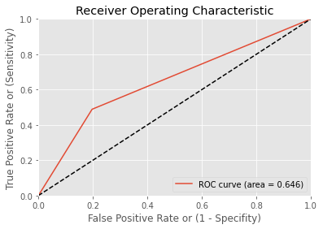

```python
from sklearn.metrics import roc_curve
from sklearn.metrics import roc_auc_score

# Compute fpr, tpr, thresholds and roc auc
fpr, tpr, thresholds = roc_curve(y_test, y_pred_lr)
roc_auc = roc_auc_score(y_test, y_pred_lr)

# Plot ROC curve
plt.plot(fpr, tpr, label='ROC curve (area = %0.3f)' % roc_auc)
plt.plot([0, 1], [0, 1], 'k--')  # random predictions curve
plt.xlim([0.0, 1.0])
plt.ylim([0.0, 1.0])
plt.xlabel('False Positive Rate or (1 - Specifity)')
plt.ylabel('True Positive Rate or (Sensitivity)')
plt.title('Receiver Operating Characteristic')
plt.legend(loc="lower right")
```

We can then use model.predict_proba(x_test)[:,1] to get the probabilities of label being positive for the target.

```python
# get importance
importance = lr_tuned.coef_
# summarize feature importance
sort_list = [(x.columns[i], v) for i,v in enumerate(importance[0])]

sort_list.sort(key=lambda x:x[1])
```

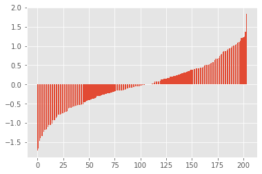

```
cat_full_Technology-Web: -1.71453
cat_full_Technology-Apps: -1.66991
cat_full_Games-Mobile Games: -1.46526
cat_full_Journalism-Video: -1.39119
cat_full_Crafts-Candles: -1.33941
cat_full_Food-Bacon: -1.33810
cat_full_Crafts-DIY: -1.22958
cat_full_Crafts-Embroidery: -1.17718
cat_full_Crafts-Crochet: -1.17300
cat_full_Music-Hip-Hop: -1.16235
cat_full_Photography-Nature: -1.10124
cat_full_Journalism-Photo: -1.05694
cat_full_Photography-Places: -1.05424
cat_full_Food-Farmer's Markets: -1.05318
cat_full_Food-Events: -1.02211
cat_full_Technology-Software: -0.93443
cat_full_Journalism-Web: -0.93288
cat_full_Food-Food Trucks: -0.92030
cat_full_Film & Video-Action: -0.88058
cat_full_Fashion-Jewelry: -0.83463
cat_full_Fashion-Childrenswear: -0.78627
cat_full_Fashion-Couture: -0.77840
cat_full_Publishing-Young Adult: -0.77808
cat_full_Fashion-Ready-to-wear: -0.76492
cat_full_Photography-People: -0.74823
cat_full_Music-R&B: -0.74178
cat_full_Fashion-Apparel: -0.73162
cat_full_Crafts-Woodworking: -0.71396
cat_full_Crafts-Crafts: -0.70795
cat_full_Film & Video-Television: -0.69989
cat_full_Games-Live Games: -0.62705
usd_goal_corrected: -0.60201
country_IT: -0.59630
cat_full_Crafts-Quilts: -0.59579
cat_full_Publishing-Academic: -0.59180
cat_full_Publishing-Fiction: -0.57108
cat_full_Design-Interactive Design: -0.56981
cat_full_Photography-Animals: -0.55697
cat_full_Crafts-Weaving: -0.54599
cat_full_Crafts-Glass: -0.54051
```

[output cut: 149 more lines]

```
cat_full_Theater-Festivals: 0.99423
cat_full_Technology-Camera Equipment: 1.00353
cat_full_Dance-Performances: 1.00502
cat_full_Music-Jazz: 1.03557
cat_full_Theater-Theater: 1.04867
cat_full_Crafts-Letterpress: 1.08059
cat_full_Music-Country & Folk: 1.09114
cat_full_Music-Indie Rock: 1.09831
cat_full_Music-Classical Music: 1.13767
cat_full_Music-Chiptune: 1.21048
cat_full_Dance-Dance: 1.21385
cat_full_Games-Tabletop Games: 1.22086
cat_full_Design-Typography: 1.23384
cat_full_Dance-Residencies: 1.36250
cat_full_Comics-Anthologies: 1.83013
```

```python
# plot feature importance
plt.bar([i for i in range(len(sort_list))], [i[1] for i in sort_list])
plt.show()

for i in sort_list:
    print('%s: %.5f' % (i[0],i[1]))
```

## Conclusion

3) From what we have observed through EDA mostly, it seems better to do a project in:

```python
print("The most promising categories to start a kickstarter in are:",", ".join(list(more_success_than_failed.keys())))
```

```
The most promising categories to start a kickstarter in are: Music-Music, Film & Video-Shorts, Games-Tabletop Games, Music-Rock, Theater-Theater, Comics-Comics, Music-Indie Rock, Music-Pop, Music-Country & Folk, Art-Public Art, Art-Illustration, Publishing-Art Books, Music-Classical Music, Comics-Co…
```

Furthermore, it seems that projects with a duration of days below one month have better chances of success.

I think our study is incomplete because we are not studying the potential creators and `backers` interactions towards the project, the comments, number of shares throughout the web are what make the success of a kickstarter project aiming towards a reasonably high amount of money, by targetting the right people and generating contributions to the project in the alloted timeline. We can see that amongst the most successful categories, the mean usd_goal between failed and successful projects is different, failed projects tend to have higher amounts of money as a goal, thus, by keeping the goal similar to previously successful projects in the same domain, the chances to see the project succeed are better.

The factors of success of a project go far beyond what we have as a dataset in this study, as the real issue seems to be how people find these projects. Kickstarter is above all the hosting platform to receive these funds. However, it is interesting to see that we were able to detect some interesting insights and finish up with a final model that has around 67% accuracy.